# Hippocampal proteome after ACT chemotherapy: ACT vs Sham

McElroy et al. (2020) Int. J. Mol. Sci., supplementary file ijms-730741 (raw iBAQ) — independent re-analysis

2026-11-14

# 1 Design

- **Tissue / model:** mouse hippocampus; ACT = doxorubicin + cyclophosphamide + paclitaxel.
- **Contrast:** ACT vs Sham, n = 4 per group. Positive log2FC = higher in ACT. MnBuOE groups are excluded on purpose (chemotherapy effect only).
- **Input:** raw MaxQuant iBAQ from Table S1 (5514 protein groups). Authors’ normalized values and statistics are not used.

# 2 Methods

| Step | Setting |
| --- | --- |
| Missing values | iBAQ = 0 treated as missing |
| Filter | ≥ 3 valid values in at least one group → 5200 proteins |
| Transformation / normalization | log2, median centering per sample |
| Imputation | MinProb-like: N(mean − 1.8 SD, 0.3 SD) per sample, seed 42 |
| Model | limma `~ 0 + group + batch` (batch = replicate pair 1–2 vs 3–4), `eBayes(trend = TRUE)` |
| Significance | BH FDR < 0.05; if nothing passes, unadjusted P < 0.01; always \|log2FC\| > 0.5 |
| Sensitivity | same model without imputation (limma handles NAs) |
| Enrichment | GSEA (GO ALL, KEGG) on signed −log10(P); ORA (GO BP) of up/down sets vs the identified proteome; gene sets 10–500, adj. P < 0.05 |

# 3 Quality control

**Missing values per sample:** Sham_1=1059; Sham_2=1190; Sham_3=208; Sham_4=276; ACT_1=967; ACT_2=575; ACT_3=215; ACT_4=320.

**Variance explained by the PCs:** PC1=34%; PC2=19%; PC3=14.7%; PC4=12%. Replicates 1–2 and 3–4 differ in depth; the replicate pair is modeled as a batch factor.

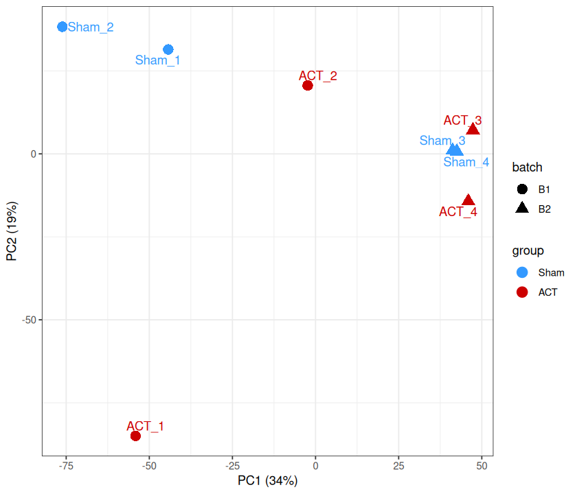

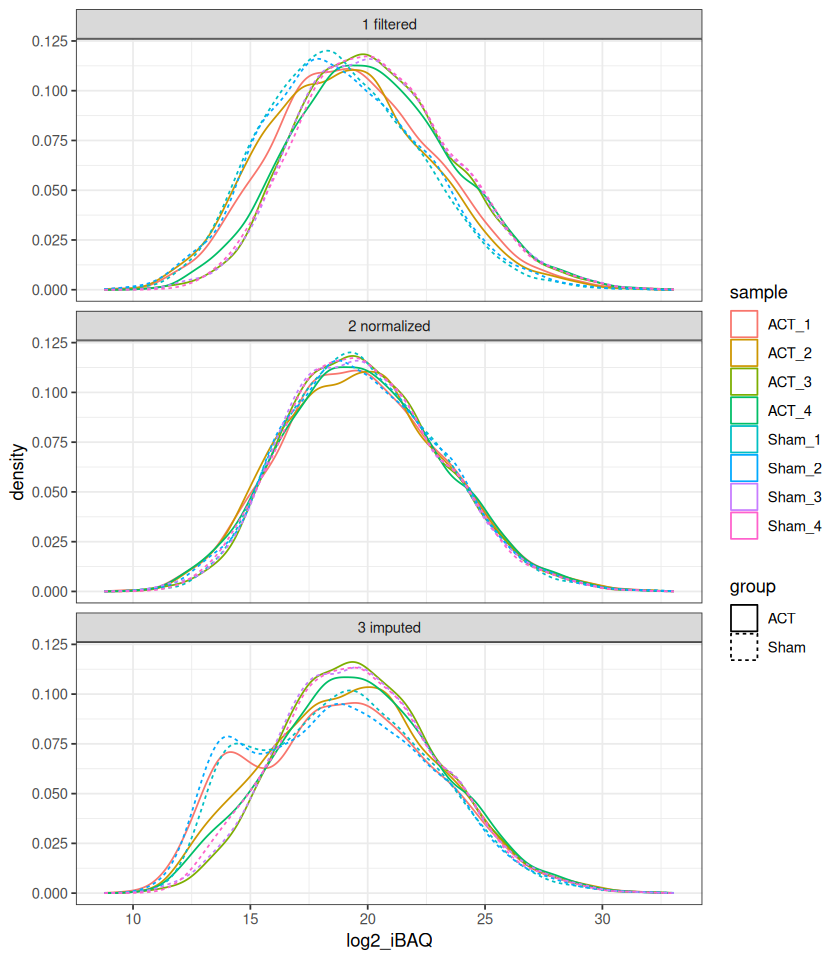

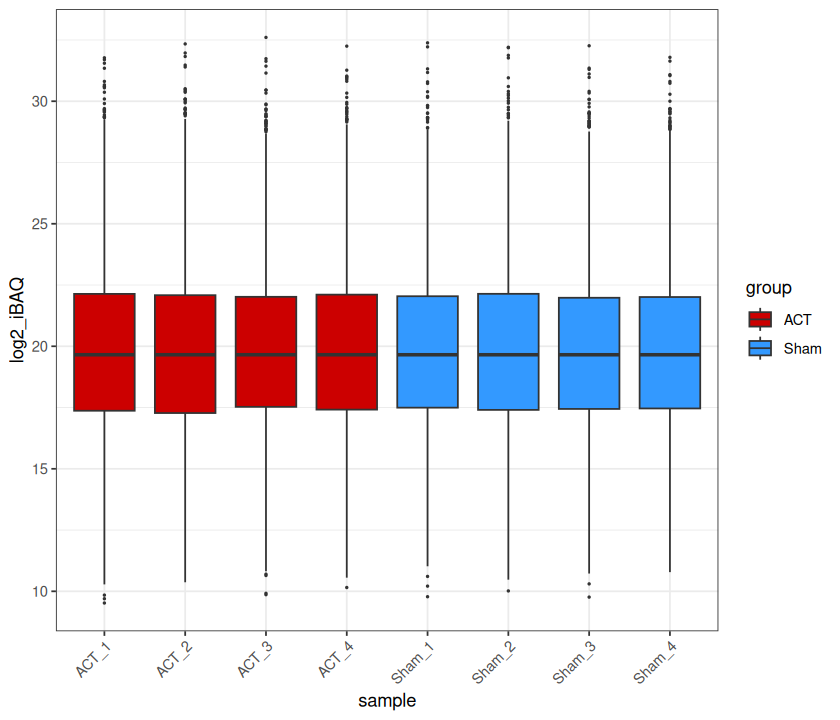

# 4 Differential abundance

**Criterion used in this run:** unadjusted P < 0.01 and |log2FC| > 0.5 → **29 up** and **9 down** in ACT (0 proteins pass FDR < 0.05 without the fold-change filter).

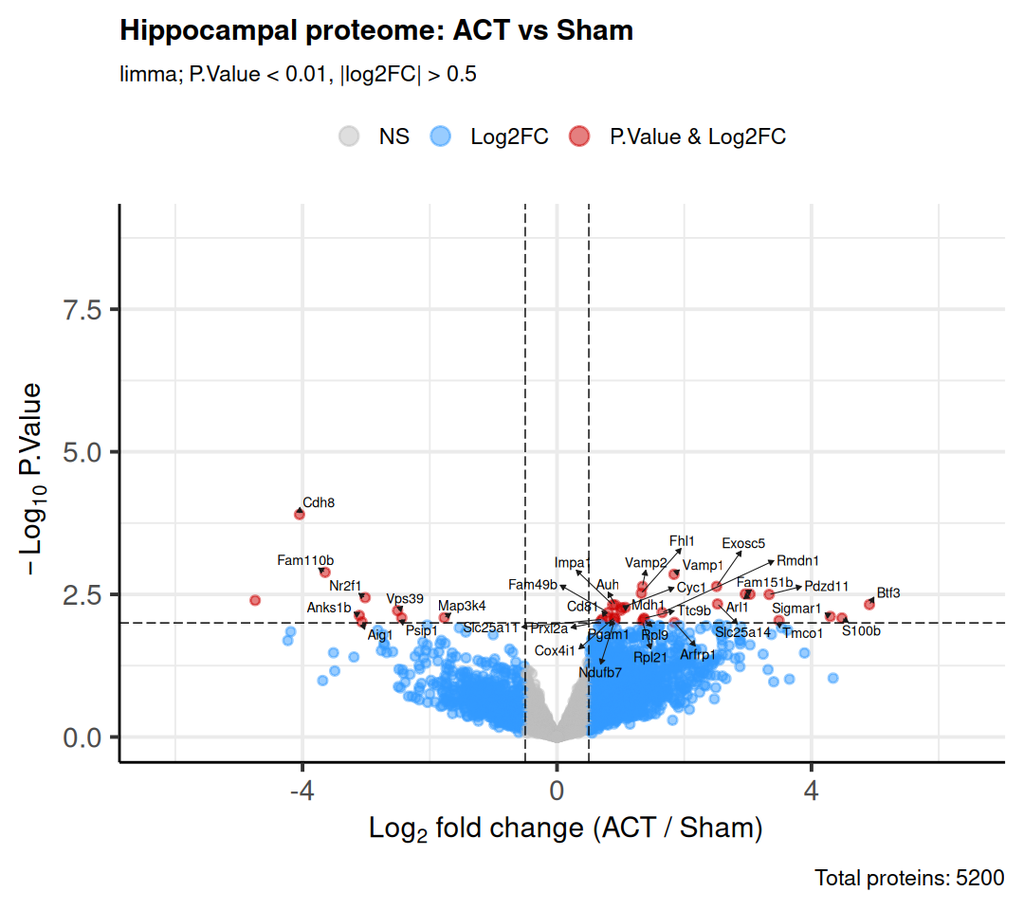

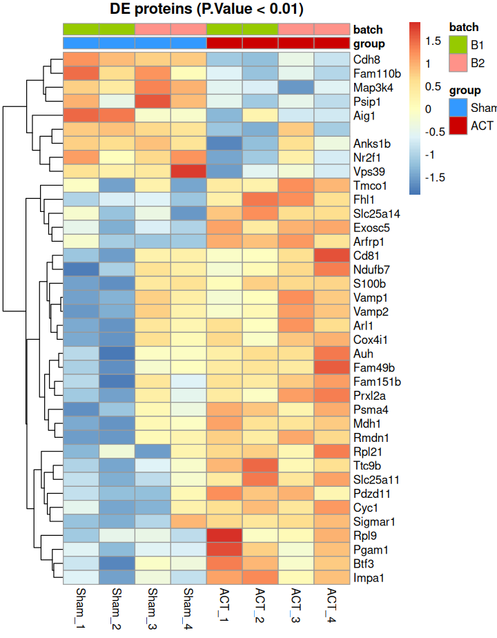

## 4.1 Differentially abundant proteins

`robust` = the call holds in the analysis without imputation (same direction and cutoffs). `miss Sham` / `miss ACT` = replicates without a quantification (imputed values).

| Symbol | Protein | Status | log2FC | P | FDR | log2FC (no imp.) | P (no imp.) | miss Sham | miss ACT | robust |
| --- | --- | --- | --- | --- | --- | --- | --- | --- | --- | --- |
| Cdh8 | Cadherin-8 | Down | -4.05 | 1.26e-04 | 6.53e-01 | -3.92 | 1.39e-04 | 0 | 1 | TRUE |
|  | Protein C19orf12 homolog | Down | -4.74 | 4.03e-03 | 7.99e-01 | -4.74 | 2.43e-03 | 0 | 0 | TRUE |
| Vamp1 | Vesicle-associated membrane protein 1 (VAMP-1 | Up | 1.84 | 1.41e-03 | 7.99e-01 | 1.84 | 1.06e-03 | 0 | 0 | TRUE |
| Vamp2 | Vesicle-associated membrane protein 2 | Up | 1.34 | 2.30e-03 | 7.99e-01 | 1.34 | 1.28e-03 | 0 | 0 | TRUE |
| Fhl1 | Four and a half LIM domains protein 1 (FHL-1) | Up | 1.33 | 3.02e-03 | 7.99e-01 | 1.33 | 2.74e-03 | 0 | 0 | TRUE |
| Fam151b | Family with sequence similarity 151, member B | Up | 2.96 | 3.12e-03 | 7.99e-01 | 2.42 | 4.95e-03 | 1 | 0 | TRUE |
| Btf3 | Transcription factor BTF3 | Up | 4.91 | 4.77e-03 | 7.99e-01 | 3.66 | 8.43e-03 | 1 | 0 | TRUE |
| Impa1 | Inositol-1-monophosphatase (EC 3.1.3.25) | Up | 0.87 | 4.82e-03 | 7.99e-01 | 0.87 | 6.14e-03 | 0 | 0 | TRUE |
| Auh | Methylglutaconyl-CoA hydratase, mitochondrial | Up | 0.92 | 4.86e-03 | 7.99e-01 | 0.92 | 6.25e-03 | 0 | 0 | TRUE |
| Mdh1 | Malate dehydrogenase, cytoplasmic (EC 1.1.1.3 | Up | 1.07 | 5.36e-03 | 7.99e-01 | 1.07 | 2.90e-03 | 0 | 0 | TRUE |
| Cyc1 | Cytochrome c1, heme protein, mitochondrial (C | Up | 1.01 | 5.41e-03 | 7.99e-01 | 1.01 | 5.06e-03 | 0 | 0 | TRUE |
| Psma4 | Proteasome subunit alpha type-4 (EC 3.4.25.1) | Up | 1.00 | 6.00e-03 | 7.99e-01 | 1.00 | 6.59e-03 | 0 | 0 | TRUE |
| Rmdn1 | Regulator of microtubule dynamics protein 1 ( | Up | 1.65 | 6.59e-03 | 7.99e-01 | 1.65 | 3.70e-03 | 0 | 0 | TRUE |
| Fam49b | Protein FAM49B | Up | 0.80 | 6.59e-03 | 7.99e-01 | 0.80 | 8.71e-03 | 0 | 0 | TRUE |
| Cd81 | Tetraspanin | Up | 0.79 | 7.92e-03 | 7.99e-01 | 0.79 | 9.94e-03 | 0 | 0 | TRUE |
| Cox4i1 | Cytochrome c oxidase subunit IV isoform 1 | Up | 0.90 | 8.08e-03 | 7.99e-01 | 0.90 | 7.39e-03 | 0 | 0 | TRUE |
| Ttc9b | Tetratricopeptide repeat protein 9B (TPR repe | Up | 1.37 | 8.29e-03 | 7.99e-01 | 1.37 | 6.55e-03 | 0 | 0 | TRUE |
| Pgam1 | Phosphoglycerate mutase (EC 5.4.2.11) (EC 5.4 | Up | 0.91 | 8.48e-03 | 7.99e-01 | 0.91 | 4.76e-03 | 0 | 0 | TRUE |
| Rpl9 | Ribosomal protein L9 | Up | 1.37 | 8.69e-03 | 7.99e-01 | 1.37 | 7.50e-03 | 0 | 0 | TRUE |
| Rpl21 | 60S ribosomal protein L21 (Ribosomal protein | Up | 1.34 | 9.37e-03 | 7.99e-01 | 1.34 | 8.22e-03 | 0 | 0 | TRUE |
| Fam110b | Protein FAM110B | Down | -3.65 | 1.30e-03 | 7.99e-01 | NA | NA | 1 | 4 | FALSE |
| Nr2f1 | COUP transcription factor 1 (Nuclear receptor | Down | -3.02 | 3.61e-03 | 7.99e-01 | -2.29 | 1.28e-01 | 1 | 2 | FALSE |
| Vps39 | CNH domain-containing protein | Down | -2.51 | 6.09e-03 | 7.99e-01 | -2.44 | 1.94e-02 | 1 | 1 | FALSE |
| Anks1b | Ankyrin repeat and sterile alpha motif domain | Down | -3.11 | 7.39e-03 | 7.99e-01 | -0.17 | 8.67e-01 | 0 | 3 | FALSE |
| Map3k4 | Uncharacterized protein | Down | -1.77 | 8.10e-03 | 7.99e-01 | -2.31 | 1.17e-01 | 2 | 1 | FALSE |
| Psip1 | PC4 and SFRS1-interacting protein | Down | -2.44 | 8.16e-03 | 7.99e-01 | NA | NA | 1 | 4 | FALSE |
| Aig1 | Uncharacterized protein | Down | -3.07 | 9.62e-03 | 7.99e-01 | NA | NA | 0 | 4 | FALSE |
| Exosc5 | Exosome complex component RRP46 (Exosome comp | Up | 2.51 | 2.30e-03 | 7.99e-01 | 2.38 | 6.10e-02 | 3 | 0 | FALSE |
| Arl1 | Uncharacterized protein | Up | 3.03 | 3.14e-03 | 7.99e-01 | 1.51 | 1.31e-01 | 2 | 0 | FALSE |
| Pdzd11 | PDZ domain-containing protein 11 | Up | 3.33 | 3.17e-03 | 7.99e-01 | 0.96 | 4.29e-01 | 3 | 0 | FALSE |
| Slc25a14 | Brain mitochondrial carrier protein 1 | Up | 2.52 | 4.66e-03 | 7.99e-01 | 1.83 | 3.86e-02 | 3 | 0 | FALSE |
| Sigmar1 | Sigma-1 receptor short form | Up | 4.30 | 7.72e-03 | 7.99e-01 | -0.51 | 5.80e-01 | 3 | 0 | FALSE |
| S100b | Protein S100 (S100 calcium-binding protein) | Up | 4.48 | 8.22e-03 | 7.99e-01 | 0.84 | 4.29e-01 | 2 | 0 | FALSE |
| Slc25a11 | Uncharacterized protein | Up | 0.71 | 8.65e-03 | 7.99e-01 | 0.71 | 1.12e-02 | 0 | 0 | FALSE |
| Tmco1 | Calcium load-activated calcium channel (CLAC | Up | 3.49 | 9.07e-03 | 7.99e-01 | 1.54 | 2.42e-02 | 2 | 0 | FALSE |
| Ndufb7 | NADH dehydrogenase [ubiquinone] 1 beta subcom | Up | 0.90 | 9.30e-03 | 7.99e-01 | 0.90 | 1.04e-02 | 0 | 0 | FALSE |
| Prxl2a | Peroxiredoxin-like 2A (Peroxiredoxin-like 2 a | Up | 0.69 | 9.41e-03 | 7.99e-01 | 0.69 | 1.47e-02 | 0 | 0 | FALSE |
| Arfrp1 | ADP-ribosylation factor-related protein 1 (AR | Up | 1.85 | 9.81e-03 | 7.99e-01 | NA | NA | 4 | 1 | FALSE |

## 4.2 Sensitivity to imputation

20 of 38 calls are robust without imputation; correlation of log2FC with vs without imputation: r = 0.655. Calls that depend on imputation are usually presence/absence patterns (protein missing in most replicates of one group) rather than quantitative changes.

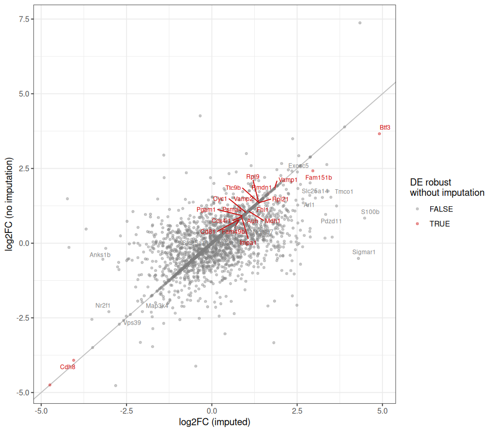

## 4.3 Model diagnostics

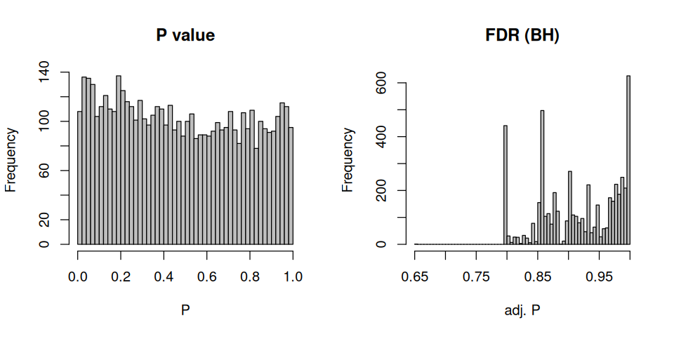

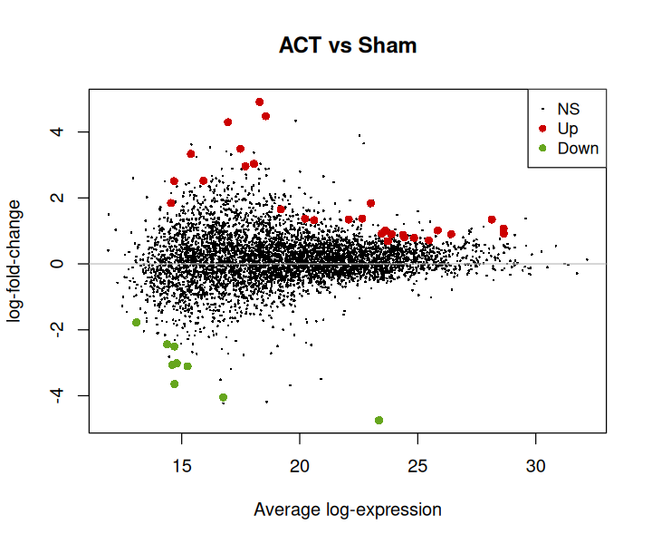

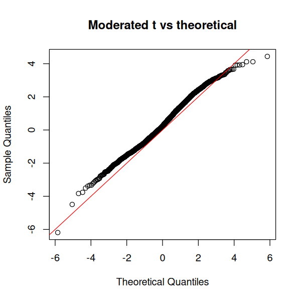

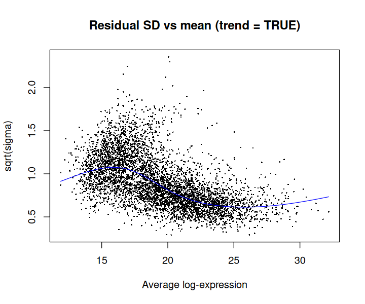

# 5 Enrichment

## 5.1 GSEA — GO

113 GO terms with adj. P < 0.05. NES > 0 = enriched among proteins higher in ACT.

| ONTOLOGY | Description | setSize | NES | p.adjust |
| --- | --- | --- | --- | --- |
| CC | mitochondrial inner membrane | 366 | 1.66 | 4.14e-07 |
| CC | organelle inner membrane | 380 | 1.63 | 2.22e-06 |
| MF | structural constituent of ribosome | 138 | 1.84 | 2.38e-05 |
| MF | G protein activity | 87 | 1.91 | 7.16e-05 |
| CC | ribosomal subunit | 153 | 1.77 | 1.81e-04 |
| CC | cytosolic ribosome | 88 | 1.87 | 2.61e-04 |
| CC | large ribosomal subunit | 91 | 1.83 | 2.95e-04 |
| BP | translation at presynapse | 43 | 2.00 | 3.18e-04 |
| BP | myoblast fusion | 52 | 1.93 | 4.52e-04 |
| BP | myotube differentiation | 73 | 1.89 | 4.52e-04 |
| BP | translation at synapse | 44 | 1.97 | 5.10e-04 |
| BP | translation at postsynapse | 44 | 1.97 | 5.10e-04 |
| MF | GTPase activity | 175 | 1.66 | 5.10e-04 |
| BP | regulation of syncytium formation by plasma membrane fusion | 46 | 1.92 | 6.30e-04 |
| BP | purine ribonucleotide biosynthetic process | 101 | 1.77 | 6.30e-04 |
| MF | chromatin binding | 132 | -1.96 | 2.94e-04 |
| CC | chromatin | 173 | -1.77 | 6.51e-04 |
| MF | double-stranded DNA binding | 123 | -1.82 | 1.24e-03 |
| MF | transcription regulatory region nucleic acid binding | 94 | -1.85 | 1.83e-03 |
| MF | sequence-specific double-stranded DNA binding | 101 | -1.88 | 2.12e-03 |
| MF | sequence-specific DNA binding | 128 | -1.73 | 3.77e-03 |
| MF | transcription cis-regulatory region binding | 92 | -1.89 | 4.92e-03 |
| MF | histone binding | 44 | -2.04 | 1.04e-02 |
| BP | spliceosomal complex assembly | 24 | -2.13 | 1.07e-02 |
| BP | adherens junction organization | 32 | -2.05 | 1.93e-02 |
| MF | RNA polymerase II cis-regulatory region sequence-specific DNA binding | 56 | -1.80 | 2.88e-02 |
| CC | Cajal body | 14 | -2.13 | 3.10e-02 |
| BP | RNA splicing | 158 | -1.52 | 3.29e-02 |
| MF | transcription regulator activity | 177 | -1.45 | 3.29e-02 |
| BP | chromatin remodeling | 149 | -1.44 | 3.29e-02 |

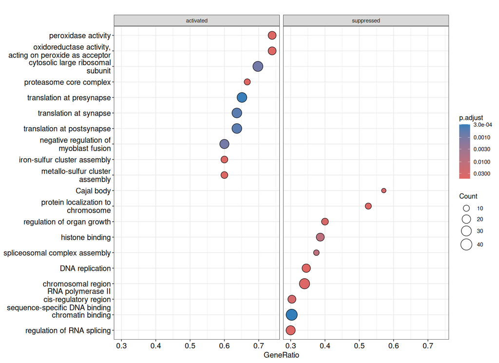

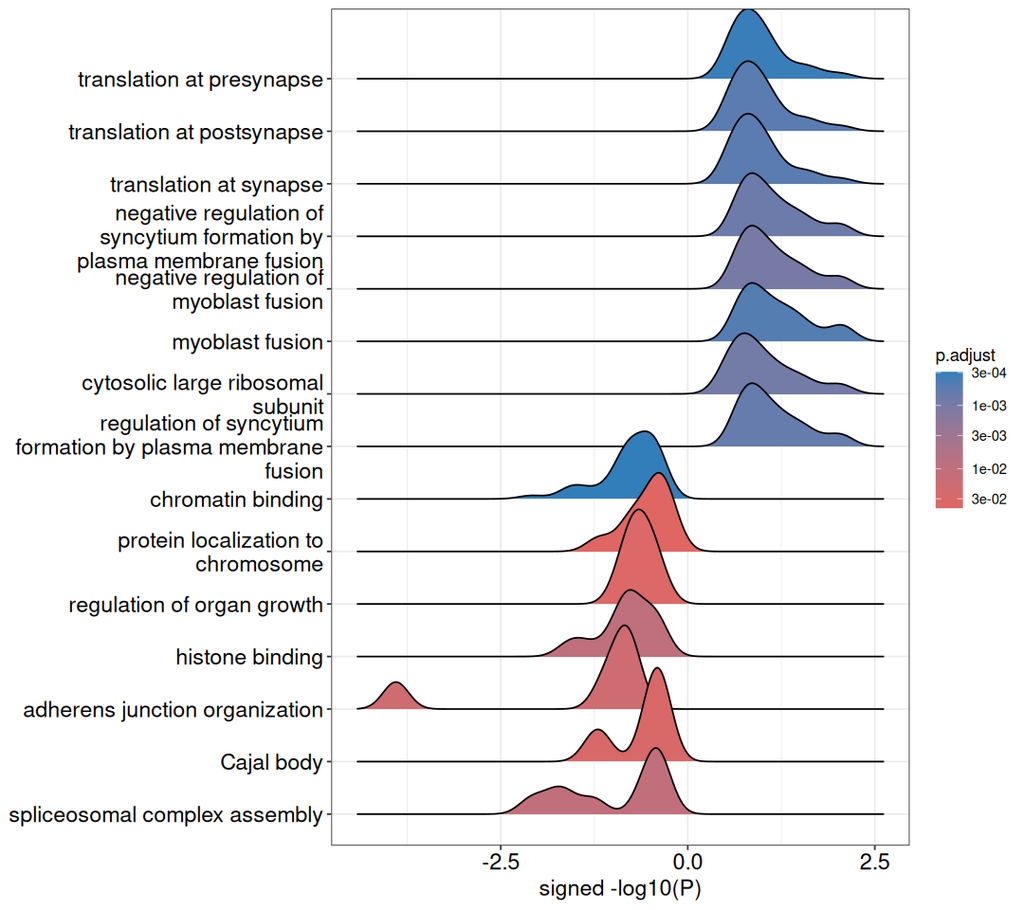

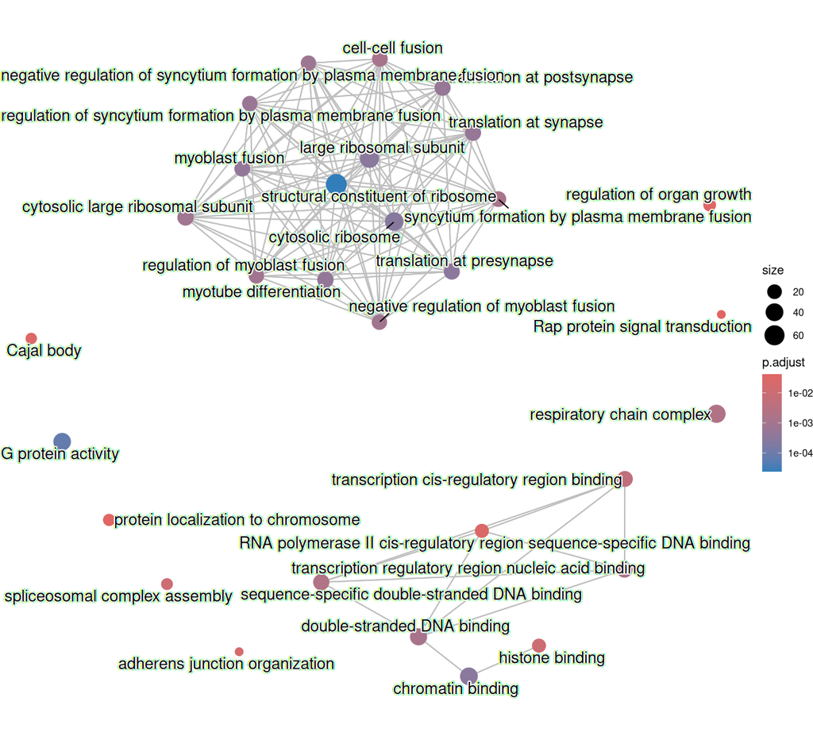

## 5.2 GSEA — KEGG

| Description | setSize | NES | p.adjust |
| --- | --- | --- | --- |
| Ribosome | 150 | 1.81 | 5.31e-06 |
| Coronavirus disease | 104 | 1.79 | 1.56e-04 |
| Oxidative phosphorylation | 92 | 1.77 | 4.49e-04 |
| Chemical carcinogenesis - reactive oxygen species | 136 | 1.70 | 4.71e-04 |
| Thermogenesis | 138 | 1.63 | 1.92e-03 |
| Non-alcoholic fatty liver disease | 87 | 1.71 | 2.54e-03 |
| Pathways of neurodegeneration - multiple diseases | 276 | 1.48 | 2.54e-03 |
| Diabetic cardiomyopathy | 124 | 1.58 | 1.15e-02 |
| Alzheimer disease | 215 | 1.44 | 1.99e-02 |
| Parkinson disease | 181 | 1.48 | 2.01e-02 |
| Amyotrophic lateral sclerosis | 231 | 1.42 | 4.02e-02 |
| Purine metabolism | 64 | 1.60 | 4.03e-02 |
| Huntington disease | 198 | 1.40 | 4.96e-02 |

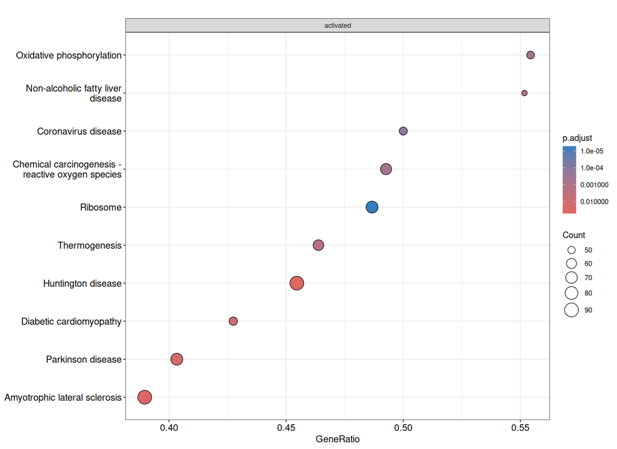

## 5.3 ORA — GO BP (up / down sets)

```
## *No significant terms for the up/down sets (few proteins against a background of the whole identified proteome).*
```

# 6 Reproducibility

Parameters (`config/config.yaml`):

```
# Parameters for the ACT vs Sham hippocampal proteomics analysis.
# Paths are relative to the project root (proteomics/).

data:
  raw_xlsx: data/ijms-730741-SI.xlsx     # supplementary file (Table S1, raw iBAQ)
  processed: data/processed.csv          # output of scripts/prepare.sh, input of the R script

results_dir: results                     # CSV tables
plots_dir: plots                         # PDF + PNG figures
reports_dir: reports                     # HTML report

seed: 42                                 # imputation and GSEA permutations

preprocessing:
  min_valid_per_group: 3                 # keep proteins quantified in >= n replicates of some group
  impute_shift: 1.8                      # MinProb: mean shift (in SD) of the imputation distribution
  impute_width: 0.3                      # MinProb: width (in SD) of the imputation distribution

de:
  fdr_cutoff: 0.05                       # BH FDR, used if any protein passes it
  nominal_cutoff: 0.01                   # unadjusted P, fallback when nothing passes FDR
  logfc_cutoff: 0.5                      # |log2FC|

enrichment:
  min_gs_size: 10
  max_gs_size: 500
  pvalue_cutoff: 0.05                    # BH-adjusted, GSEA and ORA
  run_kegg: true                         # needs internet access to rest.kegg.jp
```

**Session info of the analysis run**

```
R version 4.6.2 (2026-10-29)
Platform: x86_64-pc-linux-gnu
Running under: Ubuntu 26.04.1 LTS

Matrix products: default
BLAS:   /usr/lib/x86_64-linux-gnu/blas/libblas.so.3.12.1
LAPACK: /usr/lib/x86_64-linux-gnu/lapack/liblapack.so.3.12.1;  LAPACK version 3.12.0

locale:
 [1] LC_CTYPE=pt_BR.UTF-8       LC_NUMERIC=C
 [3] LC_TIME=pt_BR.UTF-8        LC_COLLATE=pt_BR.UTF-8
 [5] LC_MONETARY=pt_BR.UTF-8    LC_MESSAGES=pt_BR.UTF-8
 [7] LC_PAPER=pt_BR.UTF-8       LC_NAME=C
 [9] LC_ADDRESS=C               LC_TELEPHONE=C
[11] LC_MEASUREMENT=pt_BR.UTF-8 LC_IDENTIFICATION=C

time zone: America/Sao_Paulo
tzcode source: system (glibc)

attached base packages:
[1] stats4    stats     graphics  grDevices utils     datasets  methods
[8] base

other attached packages:
 [1] yaml_2.3.12            DOSE_4.7.3             enrichplot_1.99.8
 [4] org.Mm.eg.db_3.24.4    AnnotationDbi_1.75.2   IRanges_2.47.5
 [7] S4Vectors_0.51.10      Biobase_2.73.2         BiocGenerics_0.59.12
[10] generics_0.1.4         clusterProfiler_4.21.4 EnhancedVolcano_1.31.0
[13] pheatmap_1.0.13        ggrepel_0.9.8          ggplot2_4.0.3
[16] tidyr_1.3.2            dplyr_1.2.1            limma_3.99.4

loaded via a namespace (and not attached):
 [1] DBI_1.3.0               gson_0.2.2              gridExtra_2.3.1
 [4] httr2_1.3.0             rlang_1.3.0             magrittr_2.0.5
 [7] otel_0.2.0              ggridges_0.5.7          compiler_4.6.2
[10] RSQLite_3.53.3          png_0.1-9               systemfonts_1.3.2
[13] callr_3.8.0             vctrs_0.7.3             reshape2_1.4.5
[16] stringr_1.6.0           pkgconfig_2.0.3         crayon_1.5.3
[19] fastmap_1.2.0           XVector_0.53.0          labeling_0.4.3
[22] ps_1.9.3                purrr_1.2.2             bit_4.6.0
[25] cachem_1.1.0            aplot_0.3.2             jsonlite_2.0.0
[28] blob_1.3.0              tidydr_0.0.7            tweenr_2.0.3
[31] cluster_2.1.8.3         parallel_4.6.2          R6_2.6.1
[34] stringi_1.8.9           RColorBrewer_1.1-3      enrichit_0.2.7
[37] GOSemSim_2.39.4         Rcpp_1.1.2              Seqinfo_1.3.2
[40] ggtangle_0.1.5          BiocBaseUtils_1.15.1    splines_4.6.2
[43] Matrix_1.7-6            igraph_2.3.4            aisdk_1.4.12
[46] tidyselect_1.2.1        qvalue_2.45.0           processx_3.9.0
[49] lattice_0.23-1          tibble_3.3.1            plyr_1.8.9
[52] treeio_1.37.1           withr_3.0.3             KEGGREST_1.53.6
[55] S7_0.2.2                gridGraphics_0.5-1      scatterpie_0.2.6
[58] polyclip_1.10-7         Biostrings_2.81.9       pillar_1.11.1
[61] ggtree_4.3.0            ggfun_0.2.2             scales_1.4.0
[64] tidytree_0.4.8          glue_1.8.1              gdtools_0.5.3
[67] lazyeval_0.2.3          tools_4.6.2             ggnewscale_0.5.2
[70] ggiraph_0.9.6           fs_2.1.0                grid_4.6.2
[73] ape_5.8-1               nlme_3.1-172            patchwork_1.3.2
[76] ggforce_0.5.0           cli_3.6.6               rappdirs_0.3.4
[79] fontBitstreamVera_0.1.1 gtable_0.3.6            yulab.utils_0.2.5
[82] digest_0.6.39           fontquiver_0.2.1        ggplotify_0.1.4
[85] htmlwidgets_1.6.4       farver_2.1.2            memoise_2.0.1
[88] htmltools_0.5.9         lifecycle_1.0.5         httr_1.4.9
[91] GO.db_3.23.1            statmod_1.5.2           fontLiberation_0.1.0
[94] bit64_4.8.6             MASS_7.3-66
```